# Final Project for PSYC010 - Experimental Design, Methodology, and Data Analysis Procedures

**Author**: Matthew Kenney

## Introduction:

As a computer science student, I have naturally picked up an interest in machine learning and data analytics, and have become fairly familiar in working with data science packages in python. In learning data science, however, I noticed that most of the learning resources which I had access to (courses at Dartmouth, online guides on data science for programmers, etc.) focused heavily on develivering a working end-product, rather than covering statistical theory in depth and strictly adhering to guidelines set by the statistical community.

Generally, focusing on delivering an end product at the expense of some assumption-checking and due-dilligence tends to be much safer in engineering than in research, because the objective of engineering is to create working tools wheras the objective of research is to uncover the nature of the objects under study. Nevertheless, I recognize that the best data scientists and machine learning engineers are likely the ones who have a deep understanding of both programming tools and the mathematics and statistics underlying those tools.

Taking this course has helped bridge many of the gaps in my understanding that I had as a result of learning about machine learning and data science without a strong foundation in statistics. As such, I thought it would be appropriate to complete a final project in which I used my programming background to conduct an analysis with an emphasis on assumption checking and statistical soundness.

### The Analysis

Although we did not explicitly cover multiple regression in this class, I decided to conduct a multiple regression in this code and utilize many of the assumption checks and analyses that we *did* learn in class to augment my analysis. To conduct this analysis, I pulled a dataset which attempts to trace the link between measurable chemical properties in wine and percieved wine quality. Although a rather obscure dataset, I thought that this dataset satisfied by purposes perfectly, because it is composed of only ratio and interval measures in all independent variables and in the dependent variable (wine quality, rated on a scale from 1-10). While working with categorical variables is straightforward and well-documented in multiple-linear regression, it makes assumption checking and analysis of regression a bit more complex, and so I sought to avoid categorical variables in this case.

Information on the dataset I choose to use can be found in the [original paper](https://www.sciencedirect.com/science/article/pii/S0167923609001377) that generated the data, and the data can be downloaded from the UCI machine learning repository at this [link](https://archive.ics.uci.edu/ml/datasets/wine+quality). To give a bit of an intution for the kind of information this dataset contains, however, I have listed all variables reccorded in this datset below.

**Indpendent Variables:**

*Note*: units of measure have been removed in this dataset, but are documented in the referenced paper that generated this data

- fixed acidity
- volatile acidity
- citric acid
- residual sugar
- chlorides
- free sulfur dioxide
- total sulfur dioxide
- density
- pH
- sulphates
- alcohol

**Dependent Variables:**

- quality (score between 0 and 10)

*Note*: quality was determined by a panel of oenologists at a wine judging event

### Reporting Style:

The description of this project (Final Project Option 1) stated that we should follow the format of Writing Assignment 5 to report our results. I am taking some liberties here and reporting the results with rough adherance to the Writing Assignment 5 format and APA guidelines, and reporting these results throughout this Jupyter notebook rather than in a seperate document with text and figures/ tables seperated out. Although this format is, of course, unsuitable for publication, it was my opinion that keeping the code, analysis, and figures all in one cohesive document would make for an easier read and a more coherent representation of my final project.

My report is now presented below:

# Report:

The objective of this analysis is to construct a multiple regression equation to establish a numerical relationship between 11 chemical properties in wine (namely: fixed acidity, volatile acidity, citric acid, residual sugar, chlorides, free sulfur dioxide, total sulfur dioxide, density, pH, sulphates, and alcohol) and the perceived quality of the wine. Quality scores (rated 0-10) were set by a panel of oenologists at a wine tasting event. In total, the dataset under study includes information on 4898 white wines. Prior to conducting the multiple regression analysis, descriptive statistics associated with the observed data and a variety of descriptive figures were generated. Example entries from the wine datset are viewable in **Table 1**, and descriptive statistics on each of the variables included in the dataset are reported in **Table 2**. A histogram (**Figure 1**), reporting the frequencies of various wine scores showed that wine scores followed a roughly normal distribution, and that wine scores ranged between a minimum score of 3 and a maximum score of 9, even though judges were allowed to assign scores between 0 and 10.

```python
# Analysis and Descriptives
import numpy as np
import pandas as pd
from scipy.stats import describe, norm
import statsmodels.api as sm
from statsmodels.graphics.gofplots import qqplot, ProbPlot

# Graphing
from simple_colors import *
import matplotlib.pyplot as plt
import seaborn as sns
```

```python
wine = pd.read_csv('./winequality-white.csv', delimiter=';')
```

```python
print(black('Table 1: Wine Dataset Example Entries', ['bold']))
wine.head()
```

```
Table 1: Wine Dataset Example Entries
```

|  | fixed acidity | volatile acidity | citric acid | residual sugar | chlorides | free sulfur dioxide | total sulfur dioxide | density | pH | sulphates | alcohol | quality |
| --- | --- | --- | --- | --- | --- | --- | --- | --- | --- | --- | --- | --- |
| 0 | 7.0 | 0.27 | 0.36 | 20.7 | 0.045 | 45.0 | 170.0 | 1.0010 | 3.00 | 0.45 | 8.8 | 6 |
| 1 | 6.3 | 0.30 | 0.34 | 1.6 | 0.049 | 14.0 | 132.0 | 0.9940 | 3.30 | 0.49 | 9.5 | 6 |
| 2 | 8.1 | 0.28 | 0.40 | 6.9 | 0.050 | 30.0 | 97.0 | 0.9951 | 3.26 | 0.44 | 10.1 | 6 |
| 3 | 7.2 | 0.23 | 0.32 | 8.5 | 0.058 | 47.0 | 186.0 | 0.9956 | 3.19 | 0.40 | 9.9 | 6 |
| 4 | 7.2 | 0.23 | 0.32 | 8.5 | 0.058 | 47.0 | 186.0 | 0.9956 | 3.19 | 0.40 | 9.9 | 6 |

```python
print(black('Table 2: Descriptive Statistics for Wine Dataset', ['bold']))
wine.describe().T
```

```
Table 2: Descriptive Statistics for Wine Dataset
```

|  | count | mean | std | min | 25% | 50% | 75% | max |
| --- | --- | --- | --- | --- | --- | --- | --- | --- |
| fixed acidity | 4898.0 | 6.854788 | 0.843868 | 3.80000 | 6.300000 | 6.80000 | 7.3000 | 14.20000 |
| volatile acidity | 4898.0 | 0.278241 | 0.100795 | 0.08000 | 0.210000 | 0.26000 | 0.3200 | 1.10000 |
| citric acid | 4898.0 | 0.334192 | 0.121020 | 0.00000 | 0.270000 | 0.32000 | 0.3900 | 1.66000 |
| residual sugar | 4898.0 | 6.391415 | 5.072058 | 0.60000 | 1.700000 | 5.20000 | 9.9000 | 65.80000 |
| chlorides | 4898.0 | 0.045772 | 0.021848 | 0.00900 | 0.036000 | 0.04300 | 0.0500 | 0.34600 |
| free sulfur dioxide | 4898.0 | 35.308085 | 17.007137 | 2.00000 | 23.000000 | 34.00000 | 46.0000 | 289.00000 |
| total sulfur dioxide | 4898.0 | 138.360657 | 42.498065 | 9.00000 | 108.000000 | 134.00000 | 167.0000 | 440.00000 |
| density | 4898.0 | 0.994027 | 0.002991 | 0.98711 | 0.991723 | 0.99374 | 0.9961 | 1.03898 |
| pH | 4898.0 | 3.188267 | 0.151001 | 2.72000 | 3.090000 | 3.18000 | 3.2800 | 3.82000 |
| sulphates | 4898.0 | 0.489847 | 0.114126 | 0.22000 | 0.410000 | 0.47000 | 0.5500 | 1.08000 |
| alcohol | 4898.0 | 10.514267 | 1.230621 | 8.00000 | 9.500000 | 10.40000 | 11.4000 | 14.20000 |
| quality | 4898.0 | 5.877909 | 0.885639 | 3.00000 | 5.000000 | 6.00000 | 6.0000 | 9.00000 |

```
Figure 1: Histogram of Wine Quality Scores
```

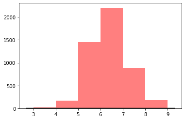

```python
print(black('Figure 1: Histogram of Wine Quality Scores', ['bold']))
# Distribution of wine scores
# Note: all scores fall within 3-9 range
plt.hist(wine['quality'], bins=[3,4,5,6,7,8,9], alpha=0.5, color='r')
mu, std = norm.fit(wine['quality'])
xmin, xmax = plt.xlim()
x = np.linspace(xmin, xmax, 100)
p = norm.pdf(x, mu, std)
plt.plot(x, p, 'k', linewidth=2);
```

## Visualizing Assumptions

Multiple regression requires a number of assumptions to be met, including the following:

- **Outliers**: outliers have been removed from the data as these can substantially affect model fit
- **Linearity**: the relationship we are trying to model is linear, and with several predictors, they combine additively
- **Collinearity**: The data does not express high intercorrelations or interassociations among the independent variables (otherwise, some of these variables are not truly independent and cannot be reliably used as predictors)
- **Normality**: both the independent and dependent variables must roughly correspond to normal distributions
- **Homoscedasticity**: variance is spread evenly among the entire range of the observed data. This assumption must hold for all predictor variables and the dependent variable

In order to assess whether or not these assumptions are met in the initial state of the wine dataset, a variety of figures were generated. These figures help to evaluate some of the above assumptions in a visual and intuitive manner. To test for outliers, a box-plot for each of the variables in this dataset was generated (see **Figure 2**). Box plots demonstrated that there were potential outlier variables in the data, with the 'fixed acitity', 'total sulfer dioxide', and the 'free sulfer dioxide' variables all showing a large number of values falling well beyond the interquartile range.

Finally, we assessed the colinearity of our variables using a correlation graph showing the coefficient of determination values associated with each variable pairing. This correlation graph (**Figure 5**) is designed to take a close look at each pairwise relationship between variables in our dataset. For the most part, the correlation graph confirmed the data does not show strong colinearities between variables. However, it is clear that there is a very strong pairwise relationship between residual sugar and density($r^2$ = 0.70), density and alcohol ($r^2$ = 0.61) and a sizable relationship between both free sulfer dioxide and total sulfer dioxide ($r^2$ = 0.38) and between total sulfer dioxide and density ($r^2$ = 0.28). The strong correlations between these variables do not come as a suprise, since they are clearly related chemical properties. Nevertheless, colinearities are problematic, leading to erroneous p-values and coefficients in the line of best-fit. *Because these variable pairs demonstrate colinearities, members of these paris are candidates for removal from our dataset.*

```
Figure 2: Boxplots for All Variables
```

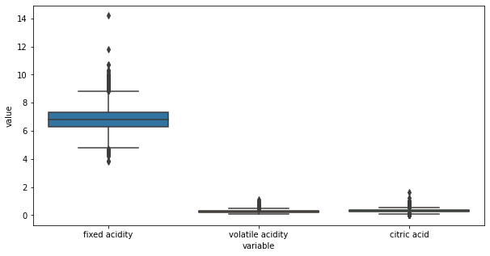

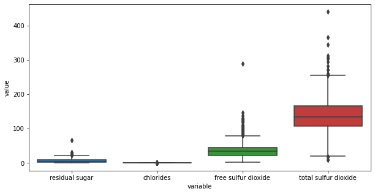

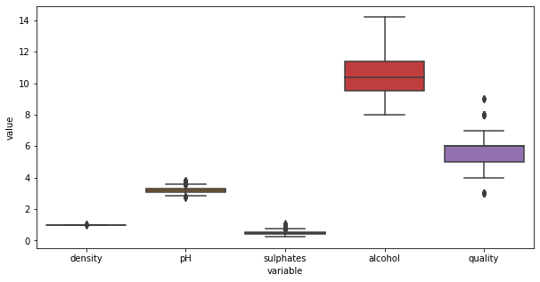

```python
# Boxplots:
print(black('Figure 2: Boxplots for All Variables', ['bold']))
fig, ax = plt.subplots(figsize=(10,5))
sns.boxplot(ax=ax, x="variable", y="value", data=pd.melt(wine.iloc[:, 0:3]))
plt.show()
fig, ax = plt.subplots(figsize=(10,5))
sns.boxplot(ax=ax, x="variable", y="value", data=pd.melt(wine.iloc[:, 3:7]))
plt.show()
fig, ax = plt.subplots(figsize=(10,5))
sns.boxplot(ax=ax, x="variable", y="value", data=pd.melt(wine.iloc[:, 7:]))
plt.show()
```

```
Figure 3: Histograms for All Variables
```

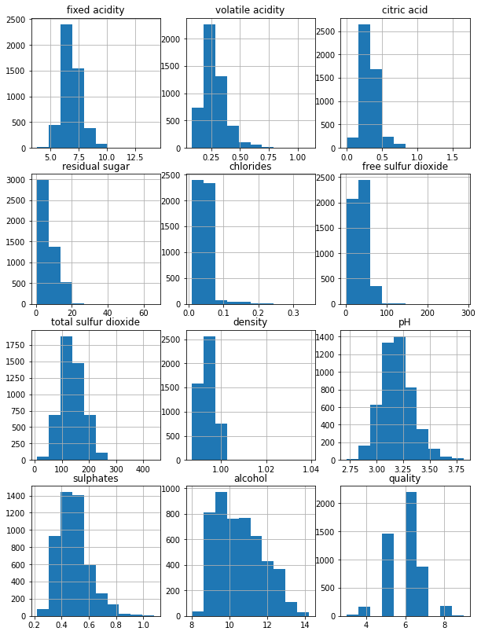

```python
print(black('Figure 3: Histograms for All Variables', ['bold']))
for n, col in enumerate(wine.columns):
    plt.subplot(4, 3, n+1)
    plt.title(col)
    wine[col].hist(ax = plt.gca(), figsize=(10,14))
```

```
Figure 4: Q-Q plots for all Variables
```

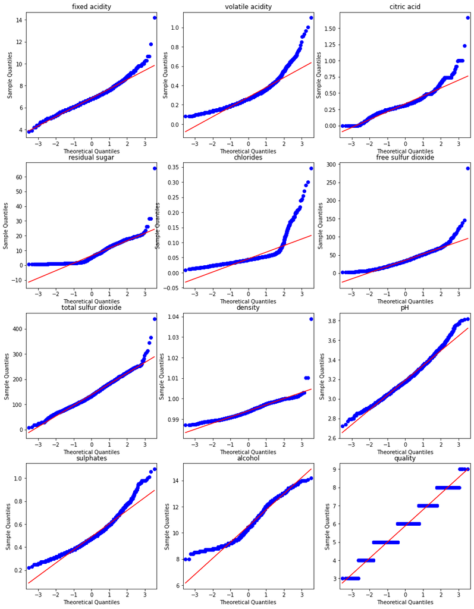

```python
print(black('Figure 4: Q-Q plots for all Variables', ['bold']))
f, axs = plt.subplots(nrows=4, ncols=3, figsize=(15,20))
for n, col in enumerate(wine.columns):
    ax = axs[n//3][n%3]
    ax.title.set_text(col)
    qqplot(wine[col], line='s', ax=ax)
```

```
Figure 5: Correlation (R^2) Heatmap
```

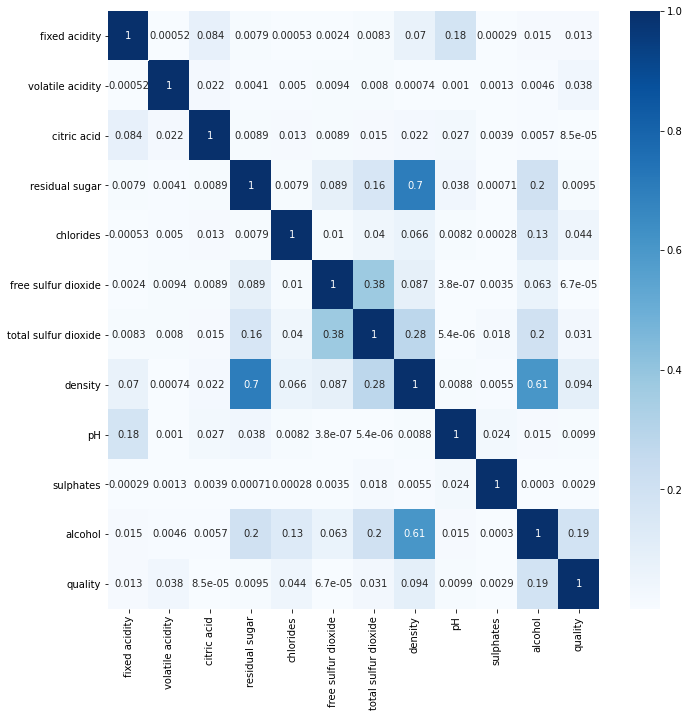

```python
print(black('Figure 5: Correlation (R^2) Heatmap', ['bold']))
fig, ax = plt.subplots(figsize=(11,11))
# wine.corr() returns the r values representing the strength of the relationship
# between each pair of variables in our dataset
sns.heatmap(wine.corr()**2, annot=True, cmap='Blues', ax=ax);
```

### Testing Assumptions:

In order to meet the assumptions of multiple linear regression, we ran a preliminary linear regression to determine which assumptions were failing at the outset of our analysis. Results of this regression are reported in **Table 3**. The result of this multiple regressions model clearly demonstrated deviations in our dataset from the desired assumptions. Specifically, we found that our dataset included outliers, and that our data (as we intuited from the pairwise correlation graph above) contained colinearities.

After colinearities were resolved, we ran a series of OLS multiple regression trials to remove outliers in our dataset (Note: The suggestion to run OLS iteratively until all samples classifying as outliers were removed was given in the [guide](https://www.adart.myzen.co.uk/reporting-multiple-regressions-in-apa-format-part-one/) I used to conduct this analysis). In order to determine which wines could be outliers in the wine dataset, we utilized residual values computed by our preliminary Ordinary Least Squares (OLS) multiple regression. The differences between the 'quality' values predicted by the OLS model and the true 'quality' values in the dataset represent the residual values in the case of our analysis. These residuals can then be standardized into z-scores (i.e. residual values are normalized for each wine in the dataset such that the mean residual is 0 and the standard deviation is 1). Once standardized residuals have been obtained, it is common practice in multiple regression workflows to remove data points which result in standardized residuals greater than or equal to 3.29 or less than or equal to -3.29 (Tabachnick & Fidell, 2007). These represent residuals in the z-distribution which have a less than 1% chance of occuring by random chance, and are therefore classified as outliers. As such, we removed all wines from the dataset matching this criteria. In total, 39 wines expressed standardized residuals with a madnitude equal to or greater than 3.29 and were therefore removed from the dataset.

Once outliers were removed, we ran OLS again to obtain our final multiple regression model. Along with this model, we generated a final matrix representing the Variance Inflation Factor (VIF) for each pairwise combination in our dataset (equal to $\frac{1}{1-r^{2}}$) to test the dataset once again for collinearities. To test for the assumption of homoscedasticity, we generated a scatterplot of standardized residuals. Finally, we and generated a Normal P-P Plot of Regression Standardized Residual.

```python
# Split data:
predictors = wine.drop(columns=['quality']) # independent variables are everything but wine quality
labels = wine['quality'] # Dependent variable is wine quality
```

```python
# Remove non-normal columns
predictors = predictors.drop(columns=['chlorides', 'volatile acidity'])
```

```python
# PRELIMINARY OLS:
X = predictors
X = sm.add_constant(X)
y = labels
```

```python
# Conduct least squares multiple regression
results = sm.OLS(y, X).fit() # OLS = Ordinary Least Squares
print('Multiple regression finished.\n\nIndependent Variables: {}\n\Dependent Variable:{}'.format(
      list(predictors.columns), 'quality'))
```

```
Multiple regression finished.

Independent Variables: ['fixed acidity', 'citric acid', 'residual sugar', 'free sulfur dioxide', 'total sulfur dioxide', 'density', 'pH', 'sulphates', 'alcohol']
\Dependent Variable:quality
```

```python
print(black('Table 3: Preliminary OLS Results', ['bold']))
results.summary()
```

```
Table 3: Preliminary OLS Results
```

OLS Regression Results

| Dep. Variable: | quality | R-squared: | 0.242 |
| --- | --- | --- | --- |
| Model: | OLS | Adj. R-squared: | 0.240 |
| Method: | Least Squares | F-statistic: | 173.2 |
| Date: | Tue, 09 Jun 2020 | Prob (F-statistic): | 6.15e-286 |
| Time: | 16:57:24 | Log-Likelihood: | -5676.6 |
| No. Observations: | 4898 | AIC: | 1.137e+04 |
| Df Residuals: | 4888 | BIC: | 1.144e+04 |
| Df Model: | 9 |  |  |
| Covariance Type: | nonrobust |  |  |

|  | coef | std err | t | P>\|t\| | [0.025 | 0.975] |
| --- | --- | --- | --- | --- | --- | --- |
| const | 189.1700 | 18.926 | 9.995 | 0.000 | 152.066 | 226.274 |
| fixed acidity | 0.1048 | 0.021 | 4.989 | 0.000 | 0.064 | 0.146 |
| citric acid | 0.2761 | 0.096 | 2.862 | 0.004 | 0.087 | 0.465 |
| residual sugar | 0.0928 | 0.008 | 12.285 | 0.000 | 0.078 | 0.108 |
| free sulfur dioxide | 0.0063 | 0.001 | 7.435 | 0.000 | 0.005 | 0.008 |
| total sulfur dioxide | -0.0015 | 0.000 | -4.026 | 0.000 | -0.002 | -0.001 |
| density | -190.3994 | 19.180 | -9.927 | 0.000 | -228.000 | -152.799 |
| pH | 0.9140 | 0.106 | 8.630 | 0.000 | 0.706 | 1.122 |
| sulphates | 0.7483 | 0.103 | 7.279 | 0.000 | 0.547 | 0.950 |
| alcohol | 0.1212 | 0.024 | 4.954 | 0.000 | 0.073 | 0.169 |

| Omnibus: | 120.572 | Durbin-Watson: | 1.622 |
| --- | --- | --- | --- |
| Prob(Omnibus): | 0.000 | Jarque-Bera (JB): | 274.516 |
| Skew: | 0.069 | Prob(JB): | 2.45e-60 |
| Kurtosis: | 4.152 | Cond. No. | 3.67e+05 |

Warnings:  
[1] Standard Errors assume that the covariance matrix of the errors is correctly specified.  
[2] The condition number is large, 3.67e+05. This might indicate that there are  
strong multicollinearity or other numerical problems.

```
Figure 6: Correlation (R^2) Heatmap After Attribute Removal
```

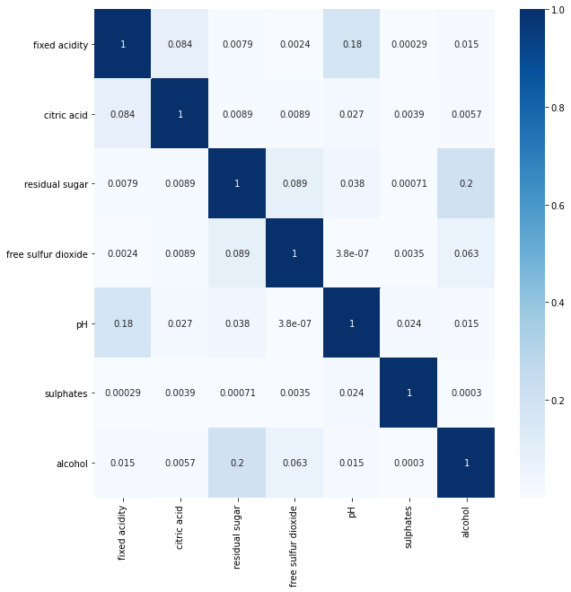

```python
# Drop covarying attributes to reduce colinearity:
predictors = predictors.drop(columns=['density', 'total sulfur dioxide'])
print(black('Figure 6: Correlation (R^2) Heatmap After Attribute Removal', ['bold']))
fig, ax = plt.subplots(figsize=(10,10))
sns.heatmap(predictors.corr()**2, annot=True, cmap='Blues', ax=ax);
```

```python
#  OLS Trials To Remove Outliers:

i = 1
while(True):

    X = predictors
    X = sm.add_constant(X)
    y = labels
    results = sm.OLS(y, X).fit() # OLS = Ordinary Least Squares

    # If there are no outliers remaining:
    if (min(results.resid_pearson) > -3.29 and max(results.resid_pearson) < 3.29):
        break

    else:
        # Remove outliers
        std_residuals = results.resid_pearson #Residuals, normalized to have unit variance.

        # Remove all outlier wines:
        orig_num_wines = len(predictors)
        predictors = predictors[abs(std_residuals) < 3.29]
        labels = labels[abs(std_residuals) < 3.29]
        remaining_wines = len(predictors)
        print("Number of Outliner wines removed on trial {} = {}".format(i, orig_num_wines - remaining_wines))

    i += 1
```

```
Number of Outliner wines removed on trial 1 = 27
Number of Outliner wines removed on trial 2 = 10
Number of Outliner wines removed on trial 3 = 2
```

### Analyzing Results:

After preparing the data extensively to meet the assumptions required by multiple regresssion, we conducted the final analysis below. We conclude the data, after adjustments were made to remove unsuitable data attributes, met all prerequisite assumptions to conduct a multiple regression analysis. Tests to determine whether or not the data met the assumption of collinearity indicated that multicollinearity was not a concern (all VIF values were below 5 and close to 1, indicating little covariance between attributes - see **Table 5**). Although the Condition Number remains high, this is merely because of the large number of indepdendent variables in this multiple regression, and can be safely ignored. Likewise, the data met the assumption of indepdendent errors (Durbin-Watson Value = 1.656, see **Table 4**).

The histogram of standardized residuals (**Figure 7**) indicated that the data contained approximately normally distributed errors, and the normal P-P plot of standardized residuals (**Figure 8**) corroborated this finding.

The data also met the assumption of non-zero variances (see Descriptive statistics in **Table 2**).

Using the method of least squares, it was found that several chemical attributes of white wine - fixed acidity, citric acid content, residual sugar content, free sulfur dioxide contant, pH, sulphates content, and alcohol content - explain a significant ammount of the variance in the value of percieved wine quality ($F(7,4851) = 238.9, p < 0.01, R^{2} = 0.256, R^{2}Adjusted = .255$).This analysis shows that all of the tested wine chemical properties were predictive of quality, albeit to different degress (see **Table 4** for coefficients, test statistics, and associated p values for each independent variable).

```python
# Conduct final least squares multiple regression
X = predictors
X = sm.add_constant(X)
y = labels
results = sm.OLS(y, X).fit() # OLS = Ordinary Least Squares
print('Multiple Regression finished.\n\nDependent variables: {}\n\npredicted variable:{}'.format(
      list(predictors.columns), 'quality'))
```

```
Multiple Regression finished.

Dependent variables: ['fixed acidity', 'citric acid', 'residual sugar', 'free sulfur dioxide', 'pH', 'sulphates', 'alcohol']

predicted variable:quality
```

```python
print(black('Table 4: Final OLS Results', ['bold']))
results.summary()
```

```
Table 4: Final OLS Results
```

OLS Regression Results

| Dep. Variable: | quality | R-squared: | 0.256 |
| --- | --- | --- | --- |
| Model: | OLS | Adj. R-squared: | 0.255 |
| Method: | Least Squares | F-statistic: | 238.9 |
| Date: | Tue, 09 Jun 2020 | Prob (F-statistic): | 2.57e-306 |
| Time: | 16:57:24 | Log-Likelihood: | -5446.7 |
| No. Observations: | 4859 | AIC: | 1.091e+04 |
| Df Residuals: | 4851 | BIC: | 1.096e+04 |
| Df Model: | 7 |  |  |
| Covariance Type: | nonrobust |  |  |

|  | coef | std err | t | P>\|t\| | [0.025 | 0.975] |
| --- | --- | --- | --- | --- | --- | --- |
| const | 0.9187 | 0.332 | 2.770 | 0.006 | 0.268 | 1.569 |
| fixed acidity | -0.0539 | 0.015 | -3.705 | 0.000 | -0.082 | -0.025 |
| citric acid | 0.2189 | 0.093 | 2.355 | 0.019 | 0.037 | 0.401 |
| residual sugar | 0.0174 | 0.002 | 7.093 | 0.000 | 0.013 | 0.022 |
| free sulfur dioxide | 0.0059 | 0.001 | 8.525 | 0.000 | 0.005 | 0.007 |
| pH | 0.2487 | 0.080 | 3.093 | 0.002 | 0.091 | 0.406 |
| sulphates | 0.3803 | 0.095 | 3.996 | 0.000 | 0.194 | 0.567 |
| alcohol | 0.3762 | 0.010 | 38.173 | 0.000 | 0.357 | 0.396 |

| Omnibus: | 28.395 | Durbin-Watson: | 1.656 |
| --- | --- | --- | --- |
| Prob(Omnibus): | 0.000 | Jarque-Bera (JB): | 30.338 |
| Skew: | 0.155 | Prob(JB): | 2.58e-07 |
| Kurtosis: | 3.233 | Cond. No. | 1.31e+03 |

Warnings:  
[1] Standard Errors assume that the covariance matrix of the errors is correctly specified.  
[2] The condition number is large, 1.31e+03. This might indicate that there are  
strong multicollinearity or other numerical problems.

```python
# Matrix of VIF values for each pairwise combination
print(black('Table 5: VIF Scores for each pairwise combination', ['bold']))
1/ (1 - predictors.corr() ** 2) # Calculation for VIF Scores
```

```
Table 5: VIF Scores for each pairwise combination
```

|  | fixed acidity | citric acid | residual sugar | free sulfur dioxide | pH | sulphates | alcohol |
| --- | --- | --- | --- | --- | --- | --- | --- |
| fixed acidity | inf | 1.091965 | 1.006992 | 1.003029 | 1.220777 | 1.000316 | 1.014063 |
| citric acid | 1.091965 | inf | 1.009234 | 1.010870 | 1.028516 | 1.003663 | 1.006089 |
| residual sugar | 1.006992 | 1.009234 | inf | 1.106629 | 1.037412 | 1.000749 | 1.250321 |
| free sulfur dioxide | 1.003029 | 1.010870 | 1.106629 | inf | 1.000010 | 1.003434 | 1.068582 |
| pH | 1.220777 | 1.028516 | 1.037412 | 1.000010 | inf | 1.024271 | 1.014012 |
| sulphates | 1.000316 | 1.003663 | 1.000749 | 1.003434 | 1.024271 | inf | 1.000291 |
| alcohol | 1.014063 | 1.006089 | 1.250321 | 1.068582 | 1.014012 | 1.000291 | inf |

```
Figure 7: Histogram of Standardised Residuals
```

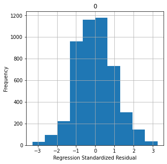

```python
print(black('Figure 7: Histogram of Standardised Residuals', ['bold']))
standard_residuals = pd.DataFrame(results.resid_pearson)
fig, ax = plt.subplots(figsize=(5,5))
standard_residuals.hist(ax=ax);
plt.xlabel('Regression Standardized Residual')
plt.ylabel('Frequency')
plt.show()
```

```
Figure 8: Normal P-P Plot of Regression Standardized Residual.
```

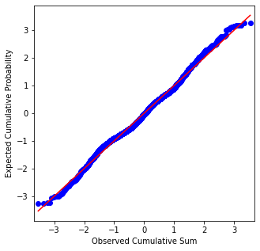

```python
print(black('Figure 8: Normal P-P Plot of Regression Standardized Residual.', ['bold']))
fig, ax = plt.subplots(figsize=(5,5))
probplot = sm.ProbPlot(results.resid_pearson)
fig = probplot.qqplot(line='s', ax=ax)
plt.xlabel('Observed Cumulative Sum')
plt.ylabel('Expected Cumulative Probability')
plt.show()
```

```
Figure 9: Scatterplot of Standardised Residuals
```

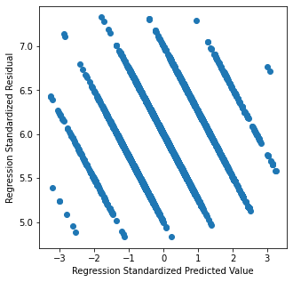

```python
print(black('Figure 9: Scatterplot of Standardised Residuals', ['bold']))
pred_vals = results.fittedvalues.copy()
residuals = results.resid_pearson
fig, ax = plt.subplots(figsize=(5,5))
plt.xlabel('Regression Standardized Predicted Value')
plt.ylabel('Regression Standardized Residual')
_ = ax.scatter(residuals, pred_vals)
```

# References:

- [Multiple Regression Using Statsmodels](https://www.datarobot.com/blog/multiple-regression-using-statsmodels/)
- [Linear Regression Diagnostic in Python with StatsModels](https://zhiyzuo.github.io/Linear-Regression-Diagnostic-in-Python/)
- Reporting Multiple Regressions in APA format, [Part One](https://www.adart.myzen.co.uk/reporting-multiple-regressions-in-apa-format-part-one/) and [Part Two](https://www.adart.myzen.co.uk/reporting-multiple-regressions-in-apa-format-part-two/)
- [Modeling wine preferences by data mining from physicochemical properties](https://www.sciencedirect.com/science/article/pii/S0167923609001377)
- Tabachnick, B. G., & Fidell, L. S. (2007). Using multivariate statistics (5th ed.). Allyn & Bacon/Pearson Education.